# Frequentist AND Bayesian A/B Testing

[figure not shown]

## Frequentist AND Bayesian A/B Testing

In this article, we will use the frequentist and bayesian approach to A/B testing to evaluate a synthetic website's Click Through Rate (CTR)

First let's generate some data. We will assume that variant A and B has a true CTR of 0.03 and 0.05 respectively. And, like in most realistic cases, we'll assume that we've only allocated 20% of the traffic to website variant B.

We're now ready to generate some data using bernoulli distributions: $B(0.03)$ of size 8,000 and $B(0.05)$ of size 2,000.

**Note:** In practice, we're not given the true CTR's and the true $\Delta$

### Business Question:

- Does Variant B performing better in terms of CTR happened by chance?

```
True CTR on A: 0.03
True CTR on B: 0.05
True CTR Delta: -0.020000000000000004
Generated Data for A: [0 0 0 0 0 0 0 1 0 0 0 0 0 0 0 0 0 0 0 0 0 0 0 0 0 0 0 0 0 0] ...
Generated Data for B: [0 0 0 0 0 0 0 0 0 0 0 0 0 0 1 0 0 0 0 0 0 1 0 0 0 0 0 0 0 0] ...
Impressions on A: 8000
Impressions on B: 2000
Clicks on A: 245
Clicks on B: 106
Proportion of Clicks for A 0.030625
Proportion of Clicks for B 0.053
Delta: -0.022375
```

### Frequentist Approach - $\chi^2$ Test

First, we need to compute a theoretical CTR under the assumption that **there are no difference between performance.**

```
Theoretical CTR: 0.0351
```

Next, we'll use the theoretical CTR to get the theoretical clicks on the 2 variants.

```
Theoretical Clicks on A: 280
Theoretical Clicks on B: 70
```

Now we can compute how likely our data is, given the assumption that there are no difference between performance. The p-value is less than the usual $\alpha=0.05$ and hence suggest that **there is indeed a difference between performance.**

```
p-value: 1.114494950251193e-06
```

### Bayesian Approach

Pros:

- You can easily incorporate domain information.
- Much more intuitive.
- Can easily express uncertainty.

Cons:

- Unless you use conjugate priors, it can be harder to solve.
- Includes intergrals.

Luckily, we have Pymc3 which will do all the heavy lifting for us. It has a set of sampling algorithms to calculate the posterior distribution. In this post, we'll use the default NUTS. (No U-Turn-Sampler)

#### Posterior Distributions

- Red lines indicates the true values
- Since we have less data for variant B, notice that it has a "fatter" posterior distribution. Hence, it suggests that we are more uncertain for our estimate.
- The distribution for delta concists mostly of negative values. And hence this suggest that indeed **performace for variant B is better.**

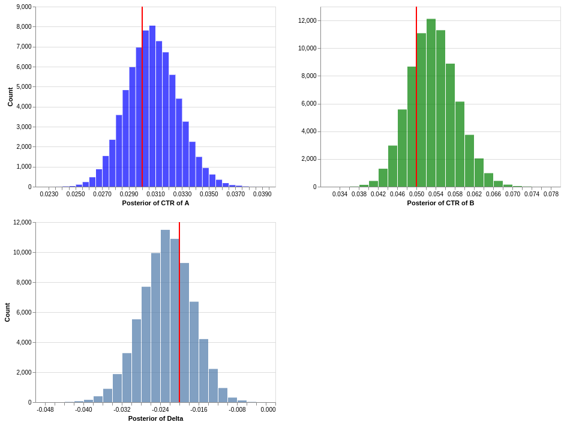